# 第 3 课

### 首先做什么？

注释：

### Facebook 匿名用户数据

注释：

```r
pf = read.delim('pseudo_facebook.tsv')
#视频用的是这个：
#pf <- read.csv('pseudo_facebook.tsv', sep = '\t')
names(pf)
```

```
##  [1] "userid"                "age"
##  [3] "dob_day"               "dob_year"
##  [5] "dob_month"             "gender"
##  [7] "tenure"                "friend_count"
##  [9] "friendships_initiated" "likes"
## [11] "likes_received"        "mobile_likes"
## [13] "mobile_likes_received" "www_likes"
## [15] "www_likes_received"
```

### 用户生日的直方图

注释：

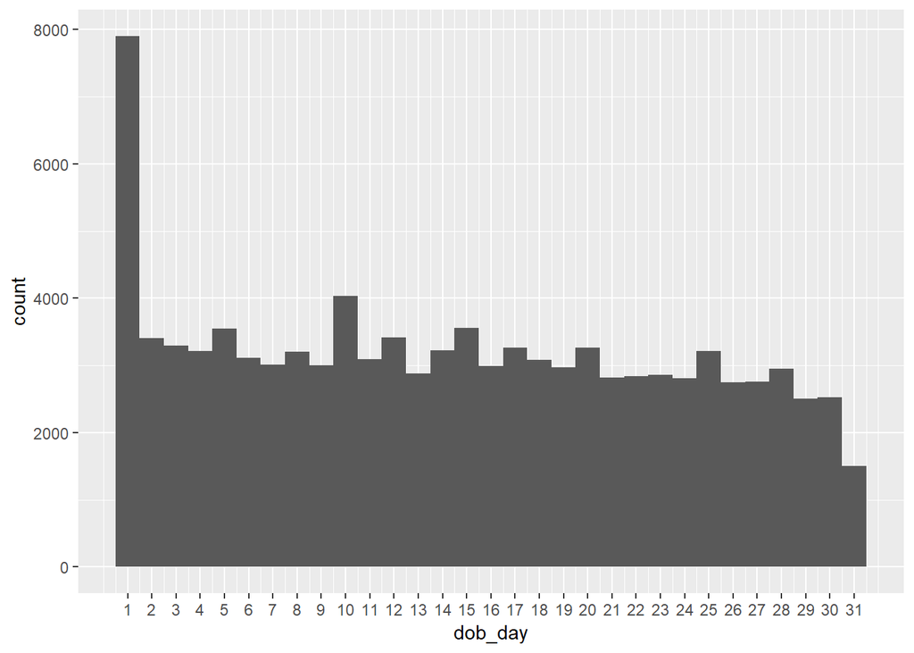

```r
library(ggplot2)
ggplot(aes(x = dob_day), data = pf) +
  geom_histogram(binwidth = 1) +
  scale_x_continuous(breaks = 1:31)
```

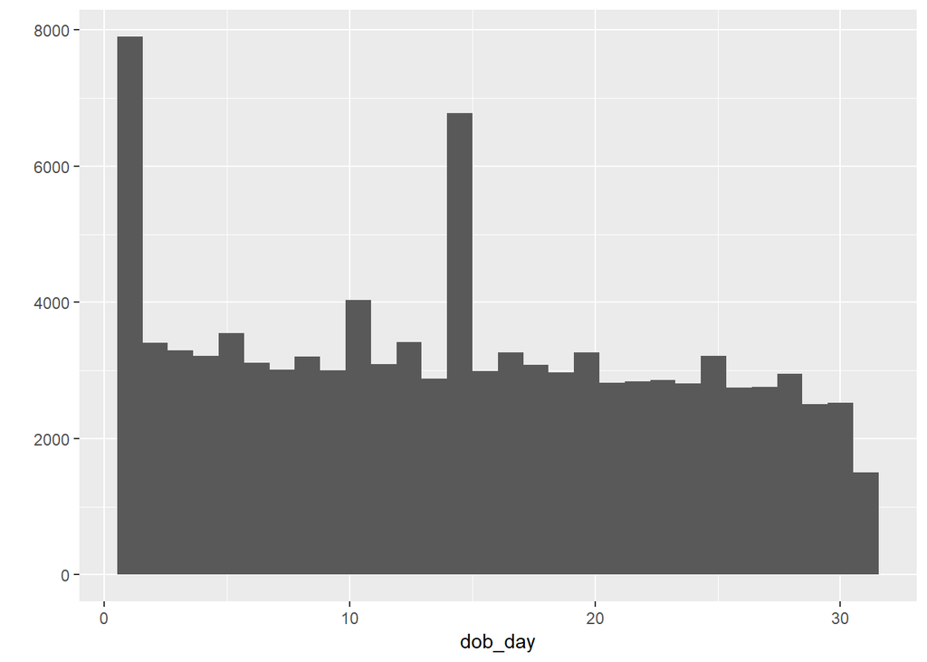

```r
library(ggplot2)
qplot(x = dob_day, data =pf)
```

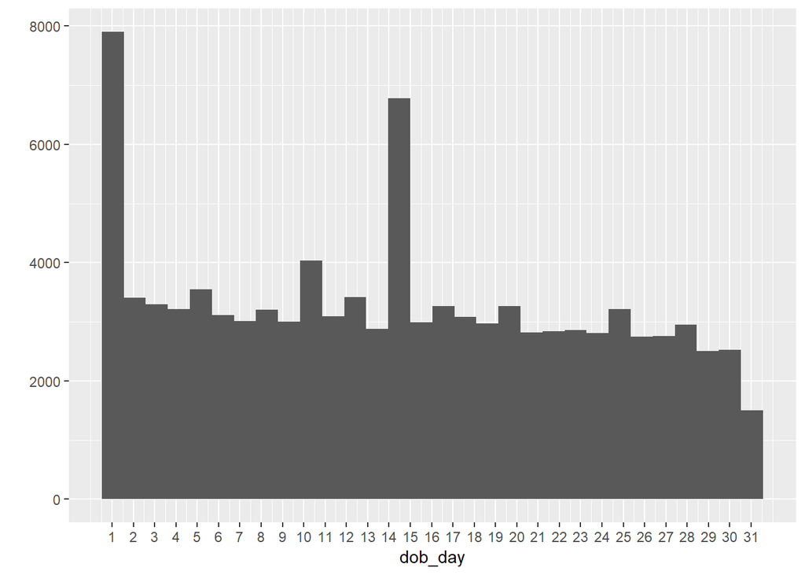

```r
qplot(x = dob_day, data =pf) +
  scale_x_continuous(breaks=1:31)
```

#### 在这个直方图中你注意到哪些事情？

注册帐号时，很多网站会将你的生日默认为1号，甚至1月1号。对于 Facebook，他们的默认是1月1日。

### Moira 的调查

注释： 人们感知的读者人数与实际读者人数相差巨大，人们严重低估读者人数。

### 估算关注量

注释：

#### 思考一下，你在 Facebook 发布特定信息或分享图片的时间。什么时间呢？

回复：

#### 你认为多少朋友会看到你的发布？

回复：

#### 思考一下，你在 Facebook 每个月发布信息或进行评论的比例。你认为这个百分比是多少？

回复：

### 自我感知的关注量

注释：

### 拆分

注释：

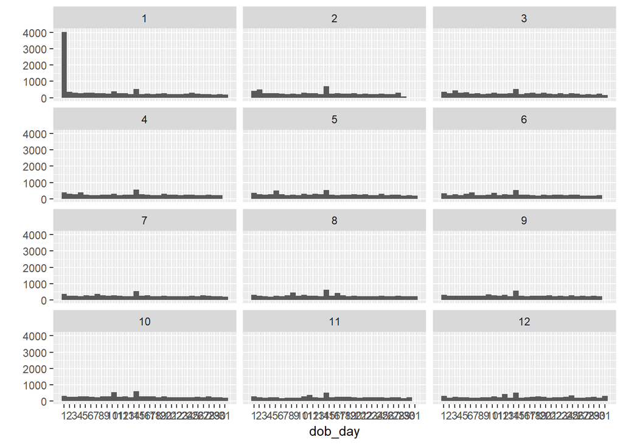

```r
#只有一个变量时用facet_wrap，两个以上时用facet_grid
qplot(x = dob_day, data = pf) +
  scale_x_continuous(breaks= 1:31) +
  facet_wrap(~dob_month, ncol = 3)
```

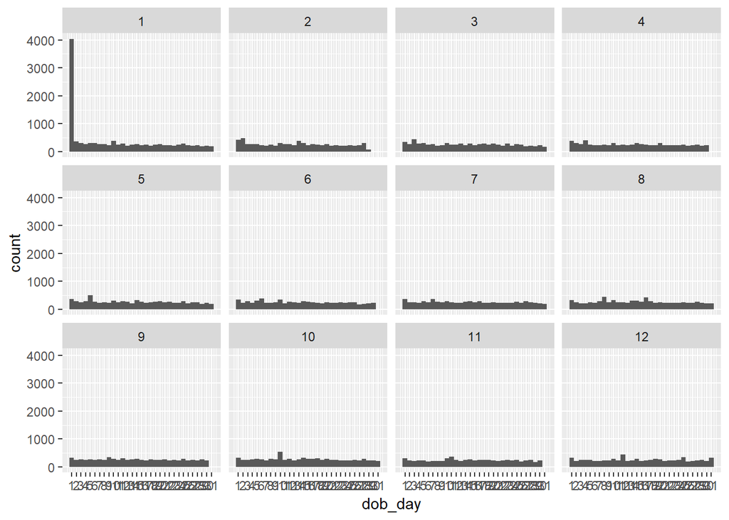

```r
ggplot(data = pf, aes(x = dob_day)) +
  geom_histogram(binwidth = 1) +
  scale_x_continuous(breaks = 1:31) +
  facet_wrap(~dob_month)
```

#### 我们再观察一下这个图。这里你发现了什么？

1月1日的值很高

### 保持怀疑态度：离群值和异常情况

注释：

### Moira 的离群值

注释：有人认为有1000万好友 #### 你认为哪些情况适用于 Moira 的离群值？ bad data about an extreme case

### 好友数

注释：

#### 你会输入哪个代码，创建朋友数量的直方图？

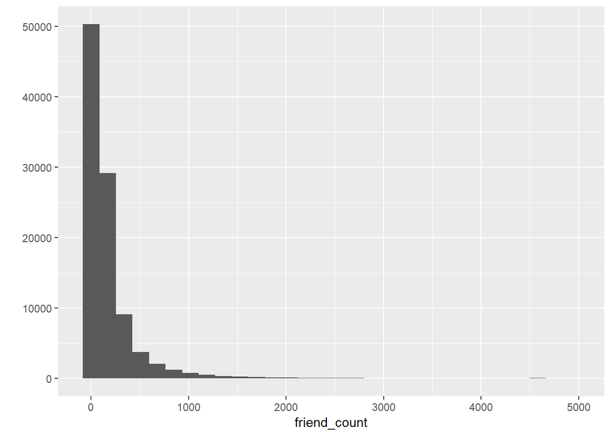

```r
qplot(x = friend_count, data = pf)
```

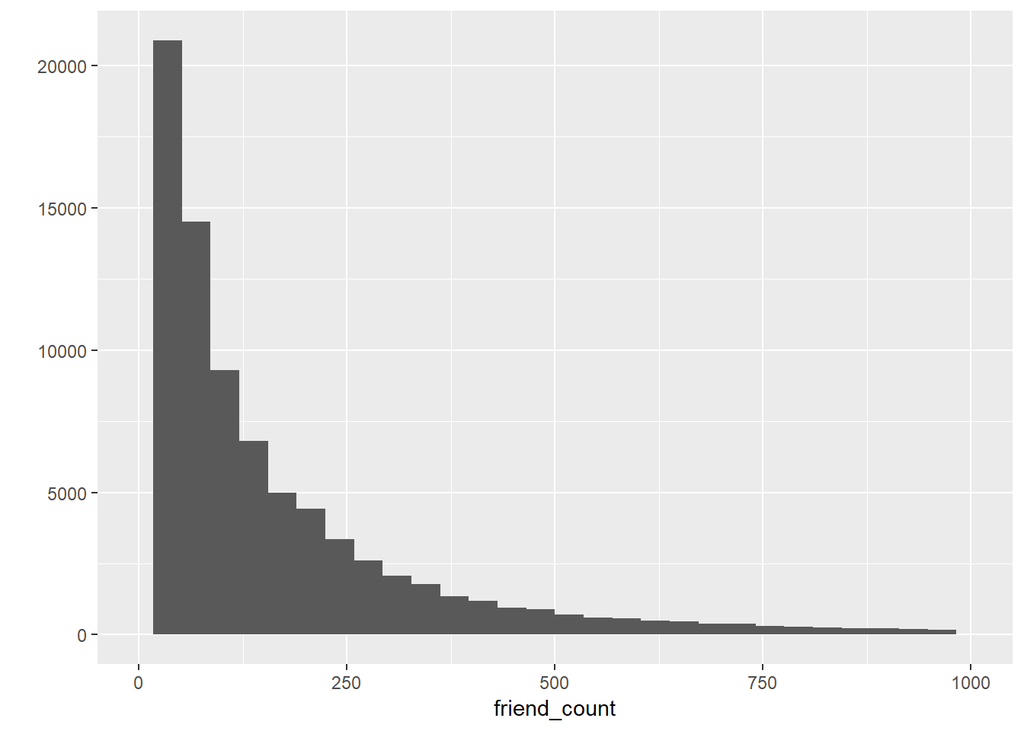

```r
#qplot(x = friend_count, data = pf, xlim = c(0,1000))
qplot(x = friend_count, data = pf) +
  scale_x_continuous(limits = c(0,1000))
```

#### 这个图与 Moira 的第一个图有哪些相似的地方？

long tail data

### 限制轴线

注释：

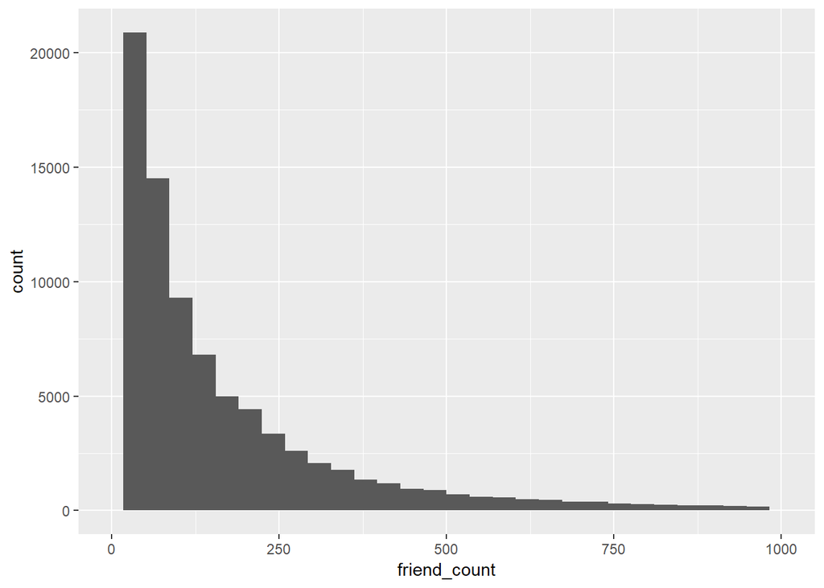

```r
ggplot(aes(x = friend_count), data = pf) +
  geom_histogram() +
scale_x_continuous(limits = c(0, 1000))
```

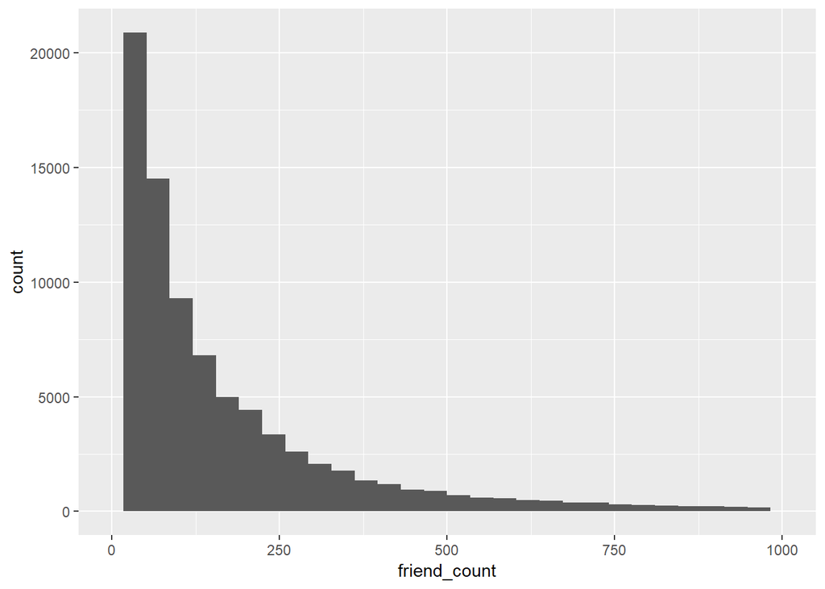

```r
ggplot(aes(x = friend_count), data = pf) +
  geom_histogram() +
scale_x_continuous(limits = c(0, 1000))
```

### 探究箱宽

注释：

### 调整箱宽

注释：

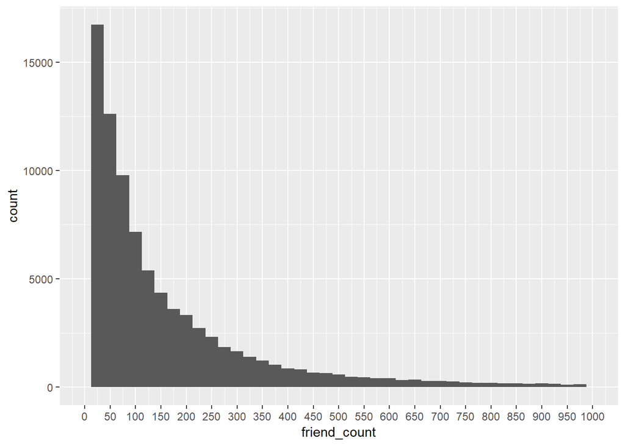

```r
ggplot(aes(x = friend_count), data = pf) +
  geom_histogram(binwidth = 25) +
  scale_x_continuous(limits = c(0, 1000), breaks = seq(0, 1000, 50))
```

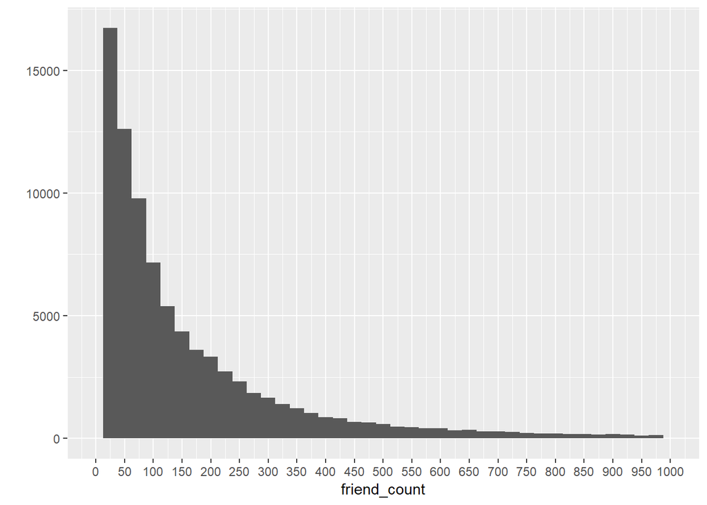

```r
qplot(x = friend_count, data = pf, binwidth = 25) +
  scale_x_continuous(limits = c(0, 1000), breaks = seq(0, 1000, 50))
```

### 拆分好友数

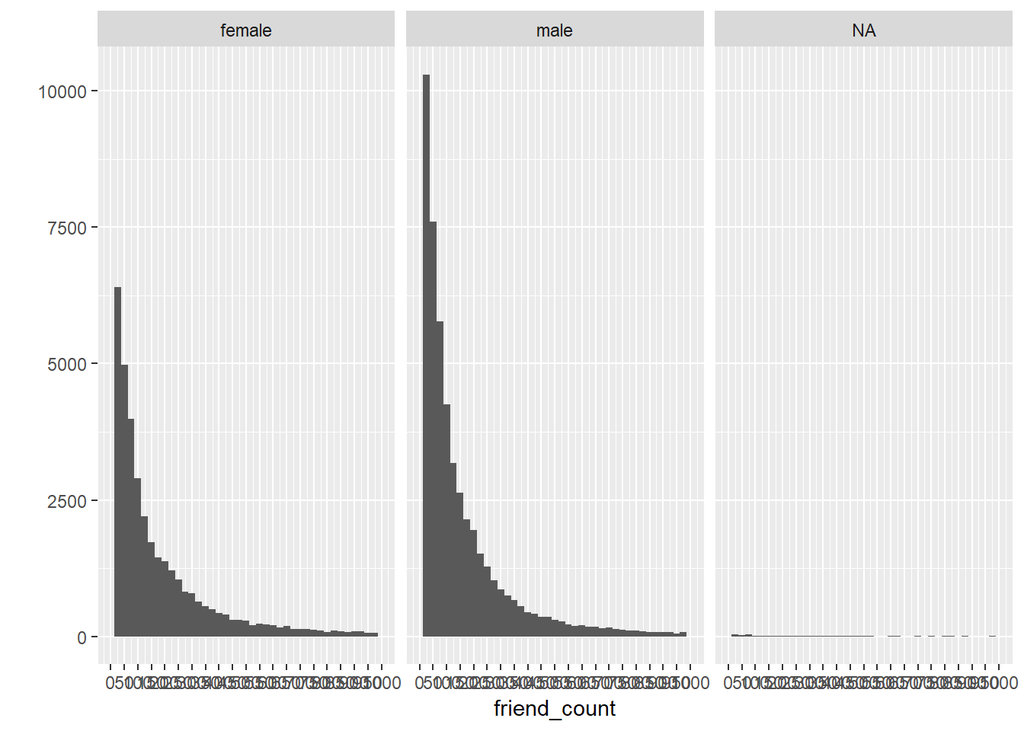

```r
# 你会输入哪个代码，创建按照性别的直方图平面？
# 将它增加到下列代码中。
qplot(x = friend_count, data = pf, binwidth = 25) +
  scale_x_continuous(limits = c(0, 1000),
                     breaks = seq(0, 1000, 50)) +
  facet_grid(. ~ gender)
```

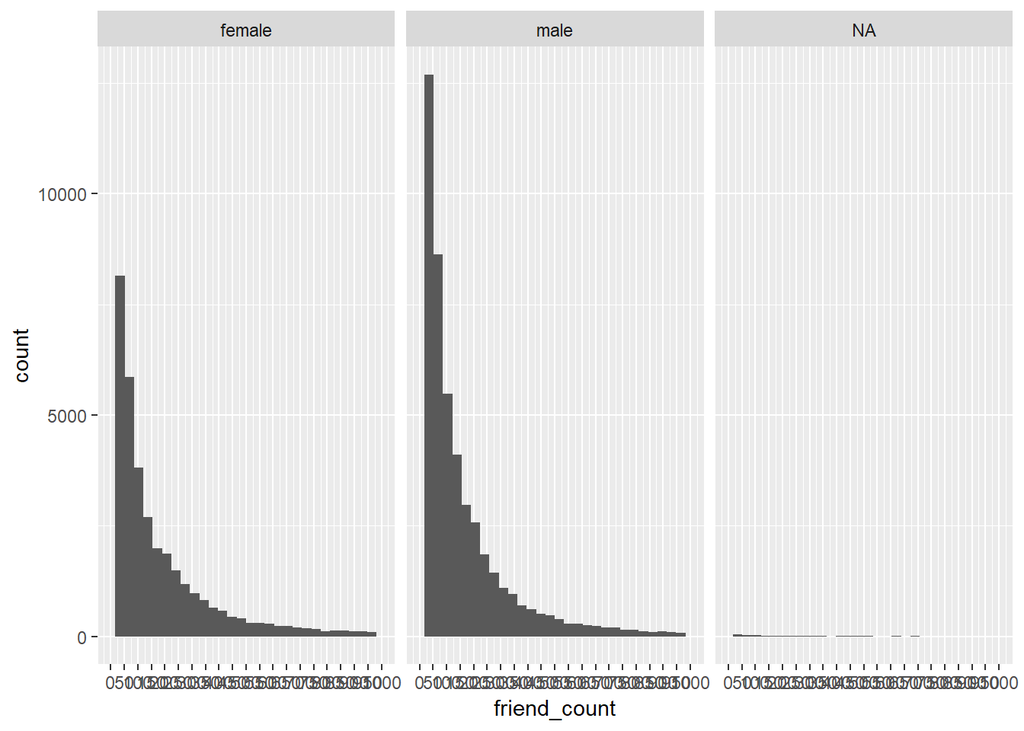

```r
ggplot(aes(x = friend_count), data = pf) +
  geom_histogram() +
  scale_x_continuous(limits = c(0, 1000), breaks = seq(0, 1000, 50)) +
  facet_wrap(~gender)
```

### 省略不适用的数值

注释：如果用了data = na.omit(pf)，则其他列的空值也被去掉了

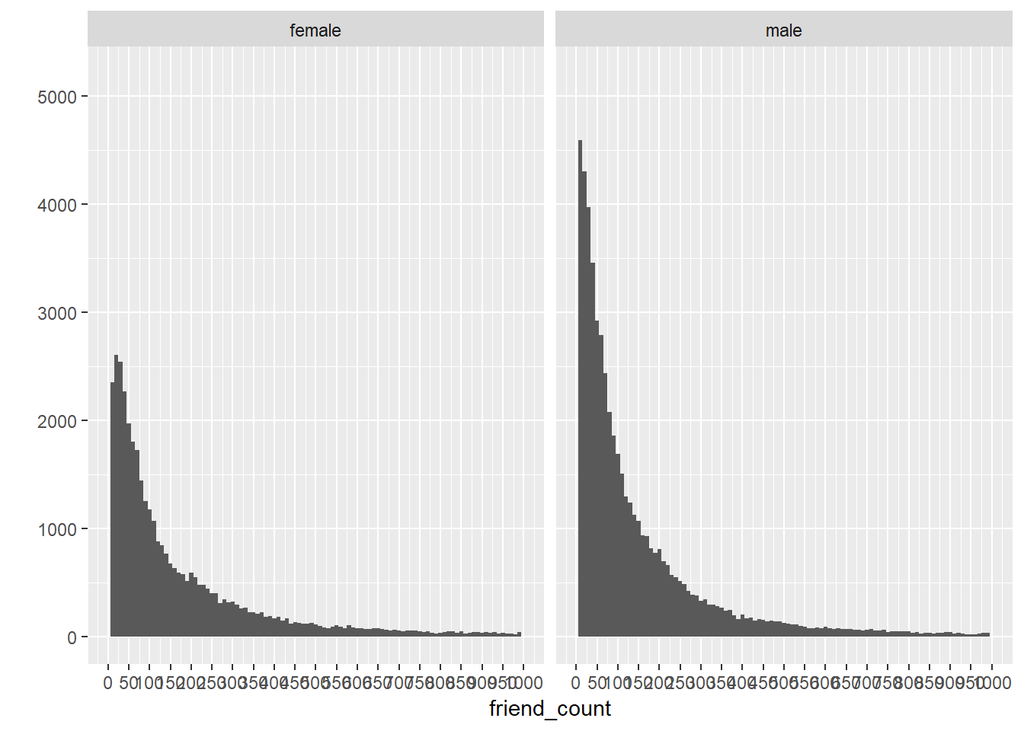

```r
qplot(x = friend_count, data = subset(pf,!is.na(gender)), binwidth = 10) +
  scale_x_continuous(limits = c(0, 1000), breaks = seq(0, 1000, 50)) +
  facet_wrap(. ~ gender)
```

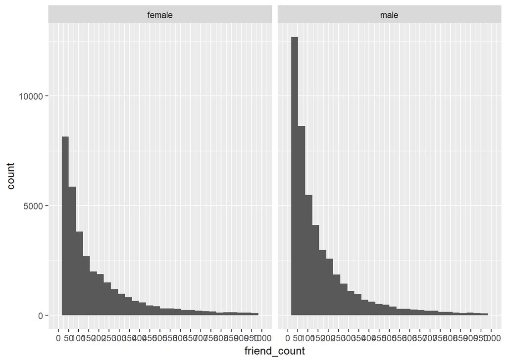

```r
ggplot(aes(x = friend_count), data = subset(pf, !is.na(gender))) +
  geom_histogram() +
  scale_x_continuous(limits = c(0, 1000), breaks = seq(0, 1000, 50)) +
  facet_wrap(~gender)
```

### ‘根据’ 性别的统计量

注释：

```r
table(pf$gender)
```

```
##
## female   male
##  40254  58574
```

```r
table(pf$gender)
```

```
##
## female   male
##  40254  58574
```

```r
by(pf$friend_count,pf$gender, summary)
```

```
## pf$gender: female
##    Min. 1st Qu.  Median    Mean 3rd Qu.    Max.
##       0      37      96     242     244    4923
## --------------------------------------------------------
## pf$gender: male
##    Min. 1st Qu.  Median    Mean 3rd Qu.    Max.
##       0      27      74     165     182    4917
```

#### 哪些人朋友更多，男性还是女性？

回复：女性

#### 女性和男性的朋友数量中位数有哪些不同？

回复：96,74

#### 为什么中位数是比平均数更好的测量方法？

回复：受极值影响小

### 使用时长

注释：

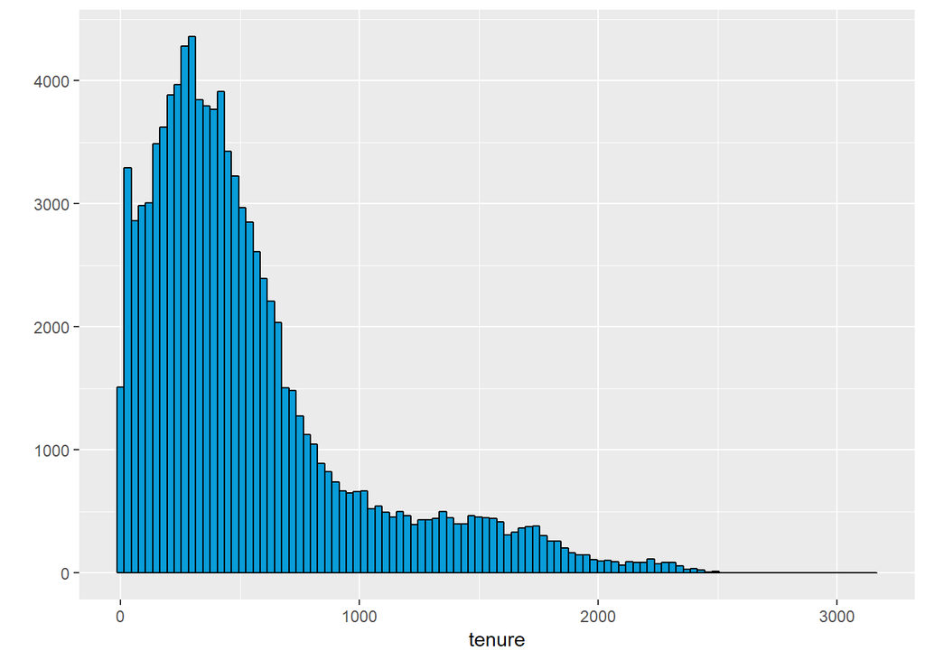

```r
qplot(x = tenure, data = pf, binwidth = 30, color = I('black'), fill = I('#099DD9'))
```

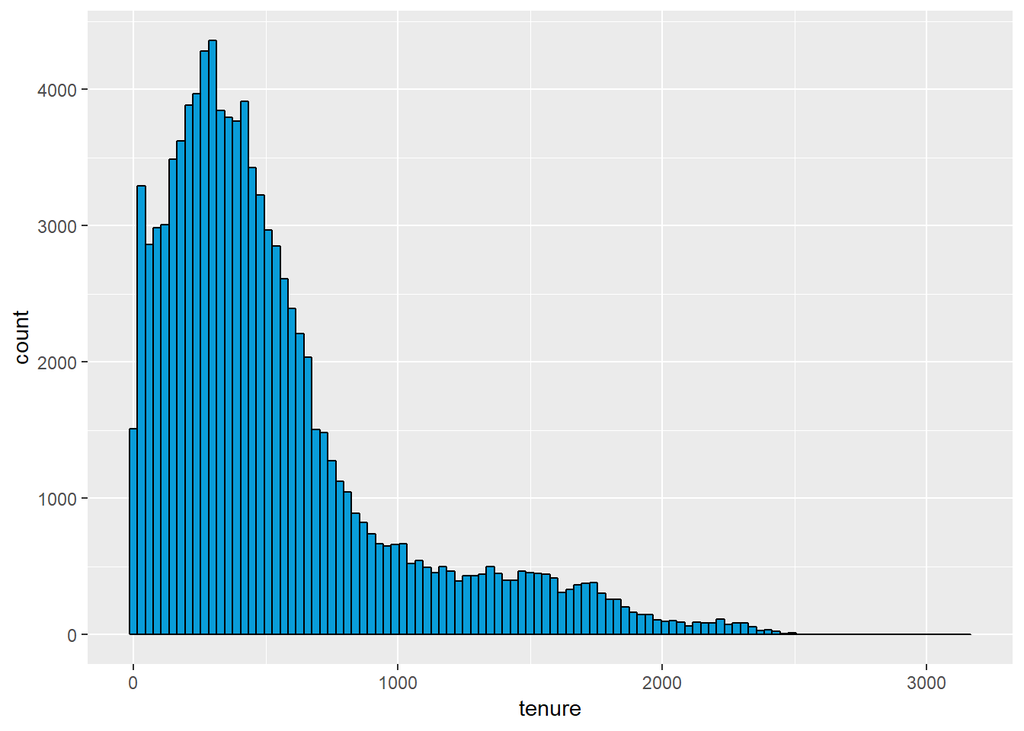

```r
ggplot(aes(x = tenure), data = pf) +
   geom_histogram(binwidth = 30, color = 'black', fill = '#099DD9')
```

***

#### 你如何按照年份创建任期的直方图？

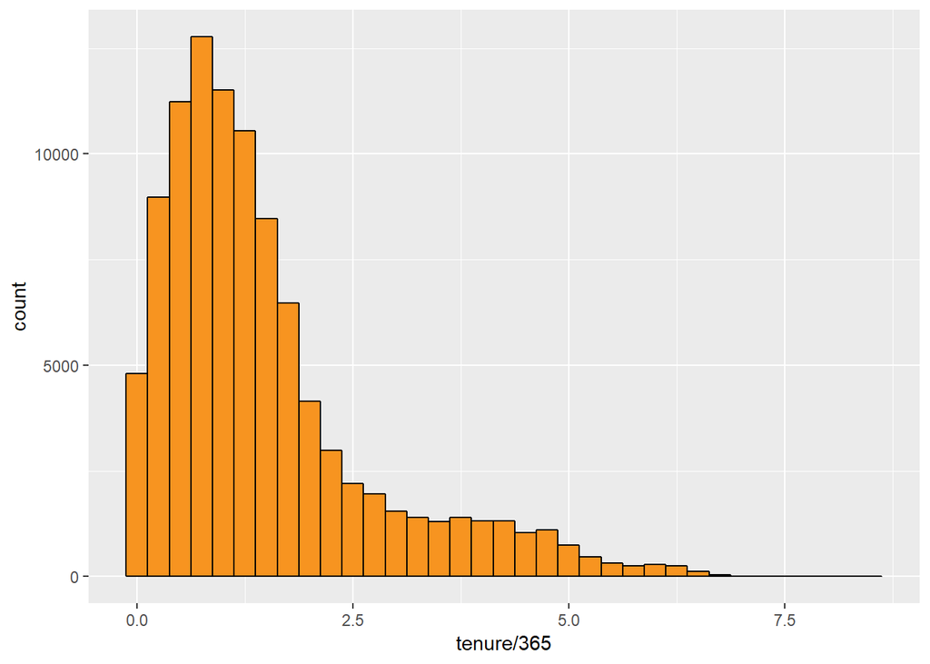

```r
ggplot(aes(x = tenure/365), data = pf) +
   geom_histogram(binwidth = .25, color = 'black', fill = '#F79420')
```

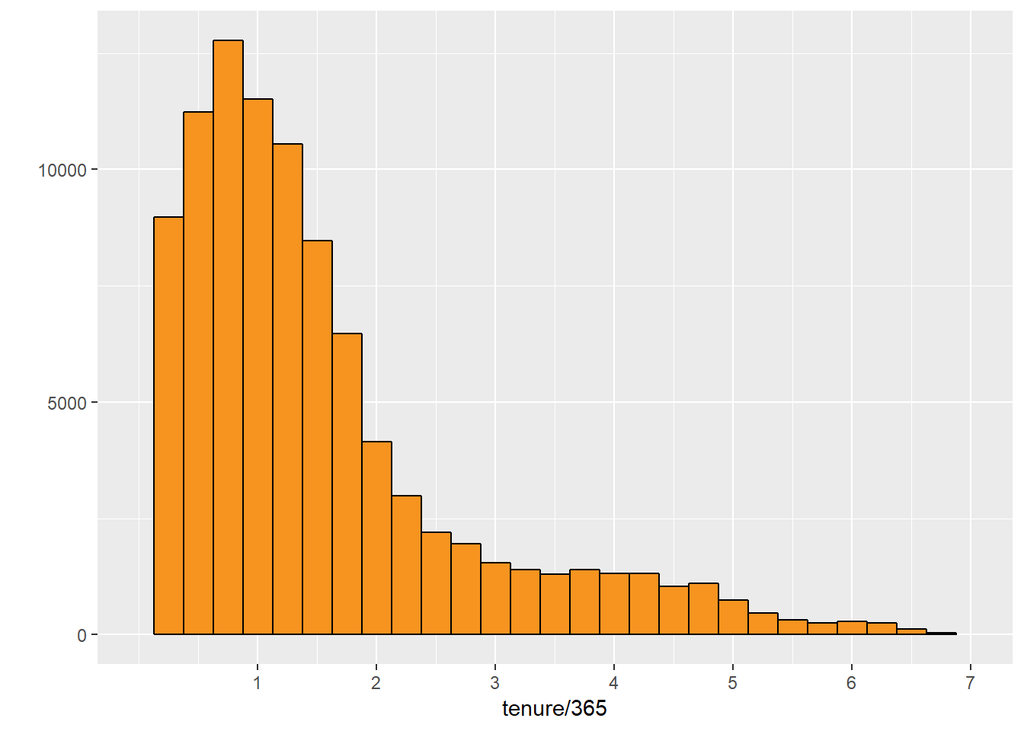

```r
qplot(x = tenure/365, data = pf, binwidth = .25, color = I('black'), fill = I('#F79420')) +
  scale_x_continuous(breaks = seq(1,7,1), limits = c(0,7))
```

### 标签图

注释：

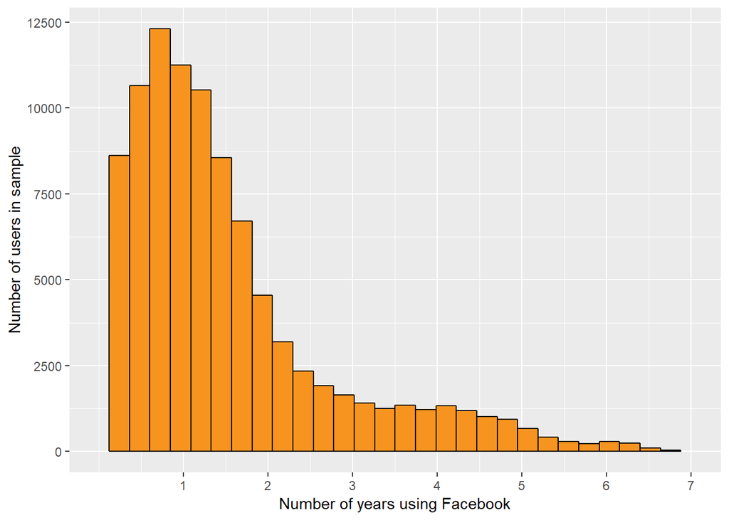

```r
qplot(x = tenure/365, data = pf,
      xlab = 'Number of years using Facebook',
      ylab = 'Number of users in sample',
      color = I('black'), fill = I('#F79420')) +
  scale_x_continuous(breaks = seq(1,7,1), limits = c(0,7))
```

### 用户年龄

注释：

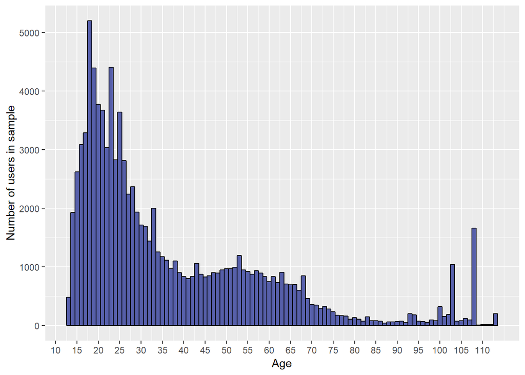

```r
qplot(x = age, data = pf, binwidth =1,
      xlab = 'Age',
      ylab = 'Number of users in sample',
      color = I('black'), fill = I('#5760AB')) +
  scale_x_continuous(breaks = seq(0,113,5))
```

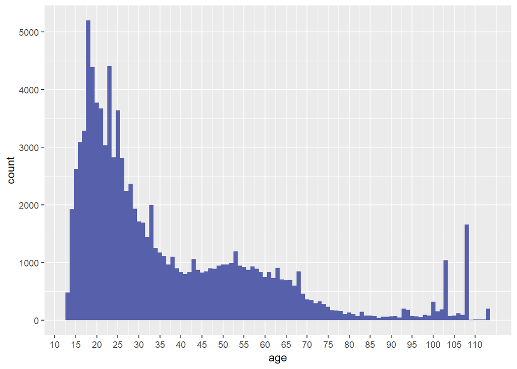

```r
ggplot(aes(x = age), data = pf) +
  geom_histogram(binwidth = 1, fill = '#5760AB') +
  scale_x_continuous(breaks = seq(0, 113, 5))
```

#### 你发现了什么？

回复：100+

### 表情包的传播

注释：

### Lada 钱包表情包

注释：

### 改变数据

注释：

```r
summary(pf$friend_count)
```

```
##    Min. 1st Qu.  Median    Mean 3rd Qu.    Max.
##     0.0    31.0    82.0   196.4   206.0  4923.0
```

```r
summary(log10(pf$friend_count))
```

```
##    Min. 1st Qu.  Median    Mean 3rd Qu.    Max.
##    -Inf   1.491   1.914    -Inf   2.314   3.692
```

```r
summary(log10(pf$friend_count +1))
```

```
##    Min. 1st Qu.  Median    Mean 3rd Qu.    Max.
##   0.000   1.505   1.919   1.868   2.316   3.692
```

```r
summary(sqrt(pf$friend_count))
```

```
##    Min. 1st Qu.  Median    Mean 3rd Qu.    Max.
##   0.000   5.568   9.055  11.088  14.353  70.164
```

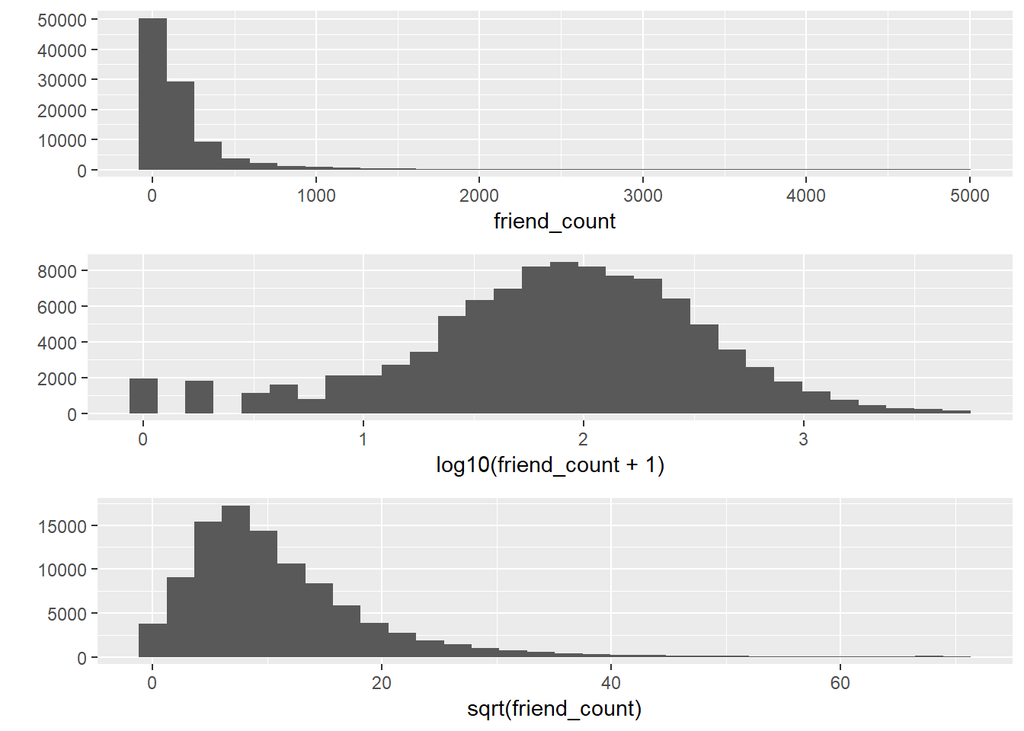

```r
library(gridExtra)
p1 <- qplot(x = friend_count, data = pf)
p2 <- qplot(x = log10(friend_count + 1), data = pf)
p3 <- qplot(x = sqrt(friend_count), data = pf)
grid.arrange(p1, p2, p3, ncol=1)
```

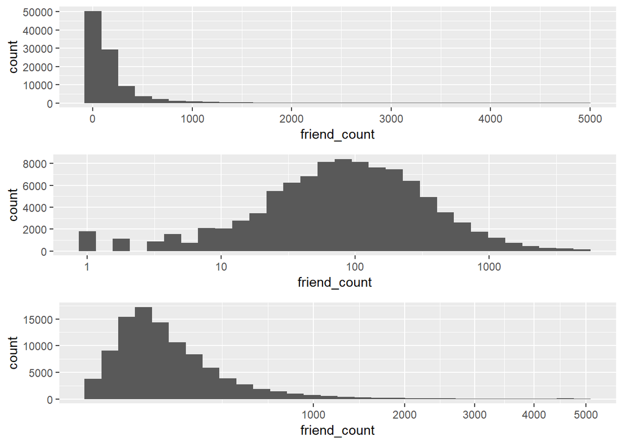

```r
p1 <- ggplot(aes(x = friend_count), data = pf) + geom_histogram()
p2 <- p1 + scale_x_log10()
p3 <- p1 + scale_x_sqrt()
grid.arrange(p1, p2, p3, ncol=1)
```

***

### 调整尺寸图层

注释：

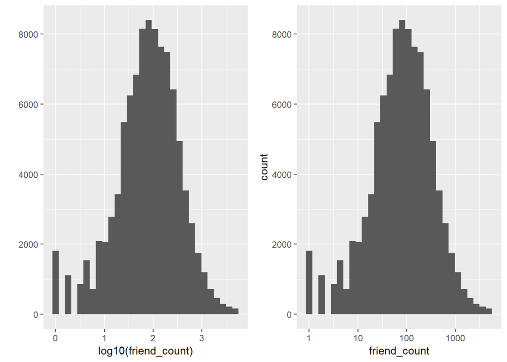

```r
logScale <- qplot(x = log10(friend_count), data = pf)
countScale <- ggplot(aes(x = friend_count), data = pf) +
  geom_histogram() +
  scale_x_log10()
grid.arrange(logScale, countScale, ncol = 2)
```

### 频数多边图

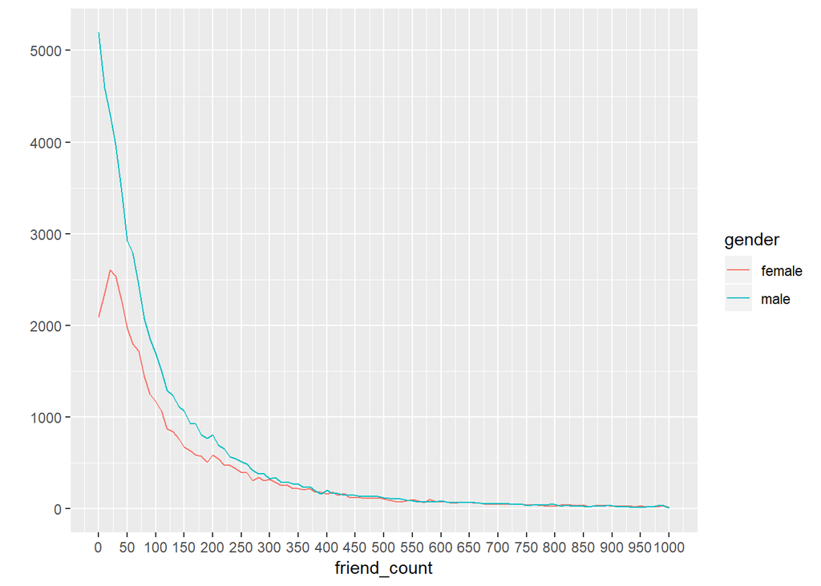

```r
qplot(x = friend_count, data = subset(pf,!is.na(gender)), binwidth = 10,
      geom = 'freqpoly', color = gender) +
  scale_x_continuous(limits = c(0, 1000), breaks = seq(0, 1000, 50))
```

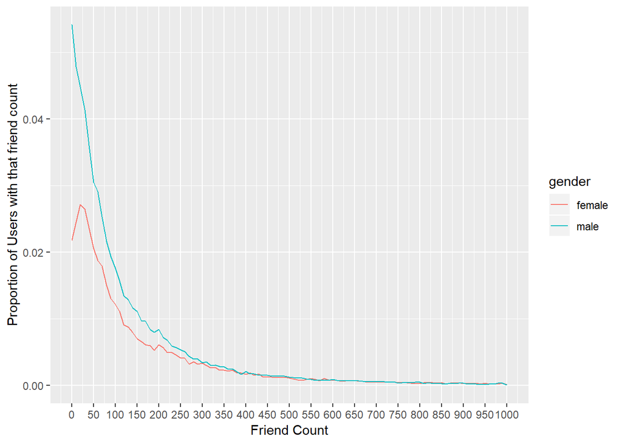

```r
qplot(x = friend_count, y = ..count../sum(..count..),
      data = subset(pf,!is.na(gender)),
      xlab = 'Friend Count',
      ylab = 'Proportion of Users with that friend count',
      binwidth = 10,
      geom = 'freqpoly', color = gender) +
  scale_x_continuous(limits = c(0, 1000), breaks = seq(0, 1000, 50))
```

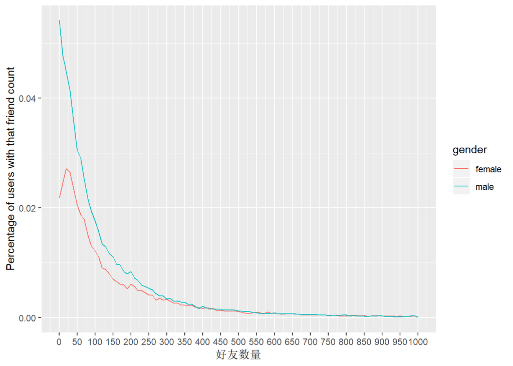

```r
ggplot(aes(x = friend_count, y = ..count../sum(..count..)), data = subset(pf, !is.na(gender))) +
  geom_freqpoly(aes(color = gender), binwidth=10) +
  scale_x_continuous(limits = c(0, 1000), breaks = seq(0, 1000, 50)) +
  xlab('好友数量') +
  ylab('Percentage of users with that friend count')
```

***

### 网页上的赞数

注释：

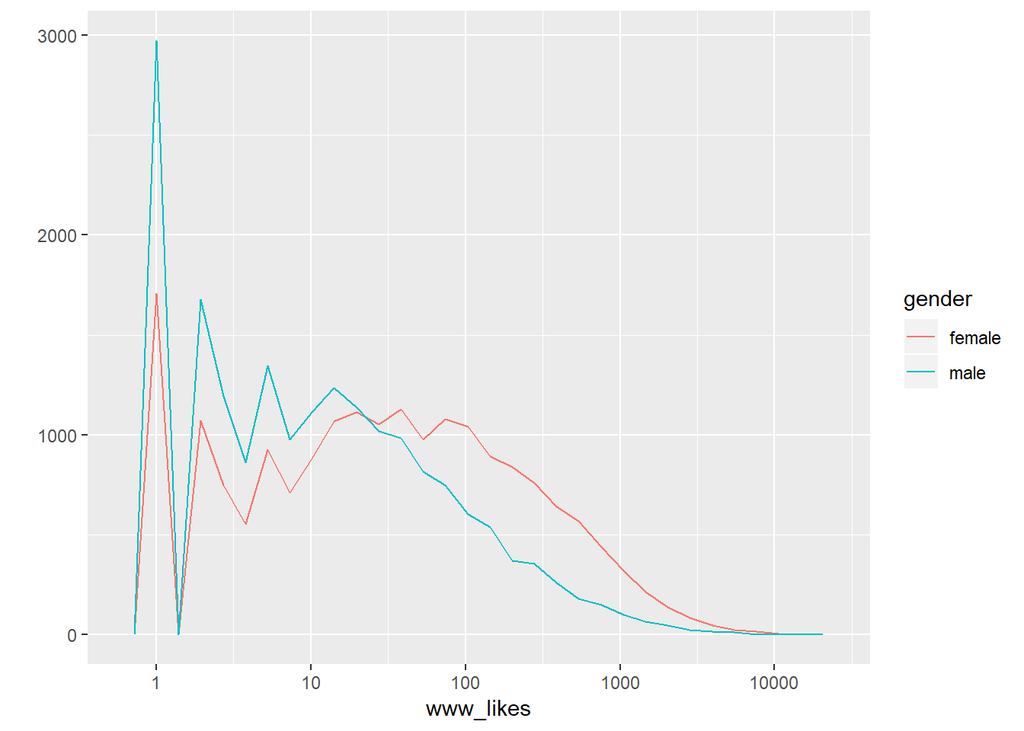

```r
qplot(x = www_likes, data = subset(pf, !is.na(gender)),
      geom = 'freqpoly', color = gender) +
  scale_x_continuous() +
  scale_x_log10()
```

```r
by(pf$www_likes, pf$gender, sum)
```

```
## pf$gender: female
## [1] 3507665
## --------------------------------------------------------
## pf$gender: male
## [1] 1430175
```

### 箱线图

注释：

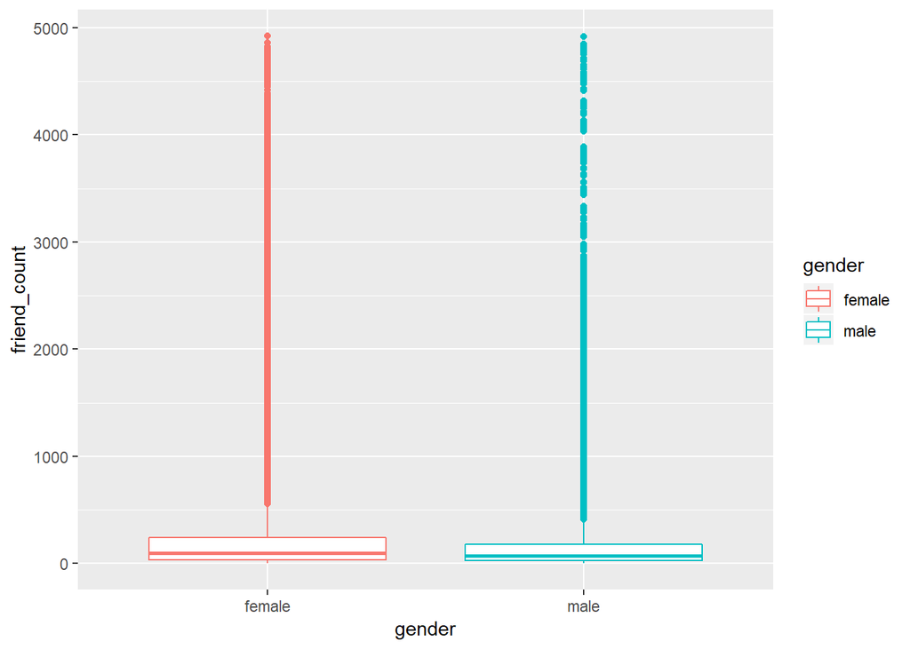

```r
qplot(x = gender, y = friend_count,
      data = subset(pf,!is.na(gender)),
      geom = 'boxplot', color = gender)
```

```r
  #scale_x_continuous(limits = c(0, 1000), breaks = seq(0, 1000, 50))
```